# Assignment 1

Huang Yingshan, Kahlbacher Fabian, Wattenberg Yannick, Aggeler Samuel

10/17/2021

# Task 1

## 1)

The probability for observing a tie is equal to the amount of present ties divided by the number of total possible ties. Let $n = \# \text{of nodes then}$:

$p = \frac{\# \text{of ties}}{\# \text{of possible ties}} = \frac{m}{n \cdot (n-1)} = \frac{174}{1190} \approx 0.146$

## 2)

The probability of observing a specific type of dyad (mutual, asymmetric and null) is the number of dyads of that type divided by the number of total possible dyads. Let $T = {n \choose 2} = \# \text{of dyads}$:

$p_M = \frac{M}{T} = \frac{52}{595} \approx 0.087$

$p_A = \frac{A}{T} = \frac{70}{595} \approx 0.118$

$p_N = \frac{N}{T} = \frac{473}{595} \approx 0.795$

## 3)

Assuming tie independence with $p = 0.146$ as the probability that a tie exists we get the following values:

$p_M' = P[x_{ij} = 1 \cap x_{ji} = 1] \stackrel{\text{tie ind}.}{=} P[x_{ij} = 1] \cdot P[x_{ji} = 1] = p^2 \approx 0.021$

$p_A' = P[x_{ij} = 1 \cap x_{ji} = 0] + P[x_{ij} = 0 \cap x_{ji} = 1] \stackrel{\text{tie ind}.}{=} 2 \cdot P[x_{ij} = 1] \cdot P[x_{ji} = 0] = 2 \cdot p \cdot (1-p) \approx 0.25$

$p_N' = P[x_{ij} = 0 \cap x_{ji} = 0] \stackrel{\text{tie ind}.}{=} P[x_{ij} = 0] \cdot P[x_{ji} = 0] = (1 - p)^2 \approx 0.729$

## 4)

The probability of observing mutual dyads in the network is four times higher than what we would expect with tie independence. Further, the probability of observing asymmetric dyads is approximately half as big in the observed network compared to the network when assuming tie independence.The probability of observing null dyads is 6.6% lower when assuming tie independence than in the observed network.

Given the differences in probability for mutual and asymmetric dyads we would argue that assuming tie independence would not be reasonable.

## 5)

If we talk about distributions we always mean the conditional uniform graph distributions.

### 5.1)

The first hypothesis is that dyadic reciprocity (proportion of dyads which are symmetric) is higher or lower in the observed network than the reference distribution $U|p$ of networks conditioned on density would suggest.

The hypothesis of the second test is the same as for the first test but here we condition on dyad census. Conditioning on dyad census means that we condition on the count of mutual, asymmetric, and null dyads giving rise to the distribution $U|MAN$.

The hypothesis of the last test is that the amount of transitive relations observed is higher or lower than the amount expected from the distribution $U|MAN$ conditioned again on the dyad census.

### 5.2)

We think that the second test does not make sense since we are testing for the dyad reciprocity conditioned on dyad census. But the dyad census contains the count of mutual dyads which already contains the information of dyad reciprocity. This is also reflected in the test results as we get exactly the same dyad reciprocity that we observed.

```r
library(sna)
library(network)
```

```r
set.seed(1908)
obsMat <- as.matrix(read.csv("matrix.csv", header=F))
cugRec1 <- cug.test(obsMat, grecip, cmode = "edges", reps = 3000)
cugRec2 <- cug.test(obsMat, grecip, cmode = "dyad.census", reps = 3000)
cugTrans <- cug.test(obsMat, gtrans, cmode = "dyad.census",  reps = 3000)
cugRec1
```

```
##
## Univariate Conditional Uniform Graph Test
##
## Conditioning Method: edges
## Graph Type: digraph
## Diagonal Used: FALSE
## Replications: 3000
##
## Observed Value: 0.8823529
## Pr(X>=Obs): 0
## Pr(X<=Obs): 1
```

```r
cugRec2
```

```
##
## Univariate Conditional Uniform Graph Test
##
## Conditioning Method: dyad.census
## Graph Type: digraph
## Diagonal Used: FALSE
## Replications: 3000
##
## Observed Value: 0.8823529
## Pr(X>=Obs): 1
## Pr(X<=Obs): 1
```

```r
cugTrans
```

```
##
## Univariate Conditional Uniform Graph Test
##
## Conditioning Method: dyad.census
## Graph Type: digraph
## Diagonal Used: FALSE
## Replications: 3000
##
## Observed Value: 0.3689482
## Pr(X>=Obs): 0
## Pr(X<=Obs): 1
```

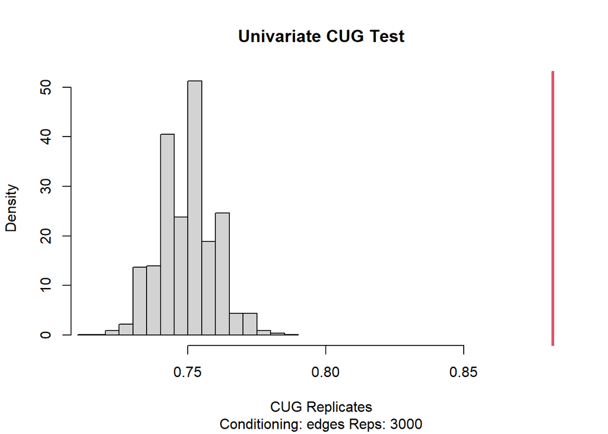

```r
plot(cugRec1)
```

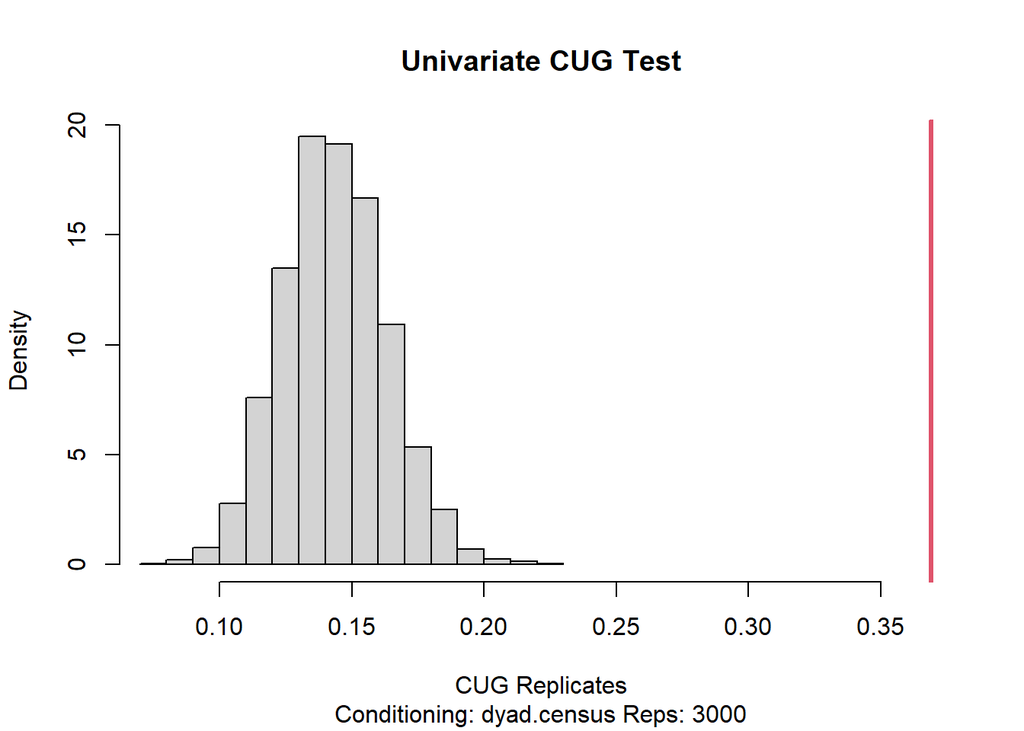

```r
#plot(cugRec2)
plot(cugTrans)
```

### 5.3)

Compared to the observed, all the generated networks have a lower number of dyad reciprocity. Thus, the empirical pvalue is 0. Therefore, there is a strong indication that our network has more dyad reciprocity then the reference distribution conditioned on density would suggests.

As we established in 5.2 the test of hypotheses 2 does not make sense we cannot draw any conclusions from the test results.

Compared to the observed, all the generated networks have a lower transitivity. Thus, the empirical pvalue is 0. Therefore, there is also significant indication that our network has more transitivity then the reference distribution conditioned on dyad census would suggests.

# Task 2

## 1)

```r
library(sna)
library(network)
```

```r
set.seed(1908)
trade2006 <- as.matrix(read.csv("trade1.csv", header=FALSE))
trade2007 <- as.matrix(read.csv("trade2.csv", header=FALSE))
attr <- read.csv("attr.csv")

permutations <- 5000

res_netlm <- netlm(y=trade2007, x=trade2006, reps=permutations, nullhyp="qapspp", intercept=T)
res_netlm$names <- c("intercept", "trade_06")

#summary(res_netlm)

res_nice <- cbind(res_netlm$coefficients, res_netlm$pgreqabs)
colnames(res_nice) <- c("Est.", "p-value")
rownames(res_nice) <- res_netlm$names
res_nice
```

```
##                Est. p-value
## intercept 2.1000241   0e+00
## trade_06  0.5646105   2e-04
```

The fitted model is: $\hat{X}=2.1 + 0.5646 * trade\_06 + \epsilon$ where trade_06 is the adjacency matrix containing the amount of goods traded by company i to company j in 2006. The residual permutation method double semi-partialing (Dekker et al., 2007) was used to obtain empirical p-values. The intercept and slope (trade_06) are statistically significant on the significance level $alpha = 0.05$. Therefore, the data indicate that both parameters are different from 0. The relationship is positive which means that for each million CHF which is traded in 2006 the amount of goods traded in 2007 increases by 0.5646 million CHF.

## 2)

```r
# Hp 1
sector <- attr[,2]
same_sector <- outer(sector,sector,"==")*1

# Hp 2
sector_sender_private <- matrix(sector,18,18,byrow=FALSE)
```

## 3)

```r
zm <- list(same_sector, sector_sender_private)
res_netlm <- netlm(trade2007, zm, reps=permutations, nullhyp="qapspp")
res_netlm$names <- c("intercept", "same_sector", "sector_sender_private")
summary(res_netlm)
```

```
##
## OLS Network Model
##
## Residuals:
##         0%        25%        50%        75%       100%
## -3.8134237 -1.4197348 -0.1565792  1.2402652  5.7000309
##
## Coefficients:
##                       Estimate   Pr(<=b) Pr(>=b) Pr(>=|b|)
## intercept              3.8099691 1.0000  0.0000  0.0000
## same_sector           -1.1002344 0.0028  0.9972  0.0028
## sector_sender_private  0.1434546 0.6336  0.3664  0.6886
##
## Residual standard error: 1.907 on 303 degrees of freedom
## Multiple R-squared: 0.0808   Adjusted R-squared: 0.07473
## F-statistic: 13.32 on 2 and 303 degrees of freedom, p-value: 2.864e-06
##
##
## Test Diagnostics:
##
##  Null Hypothesis: qapspp
##  Replications: 5000
##  Coefficient Distribution Summary:
##
##        intercept same_sector sector_sender_private
## Min     -0.59091    -4.78141              -3.86412
## 1stQ     1.82437    -0.74722              -0.75178
## Median   2.50062     0.02702               0.09409
## Mean     2.81475    -0.01884               0.03545
## 3rdQ     3.52118     0.82489               0.84962
## Max     16.15295     3.48752               2.89779
```

The parameter “same_sector” is significantly different from 0 at the significance level $\alpha=0.05$. The parameter indicates that a company sells 1.1 million CHF less goods to companies in the same sector than to companies in a different sector. Thus, the data does not support Hp. 1.

The paramter “sector_sender_private” is not significantly different from 0 at the significance level $\alpha=0.05$. It indicates that companies in the private sector sell 0.14 million CHF more goods than companies which are in the public sector but this relationship is not statistically significant. Therefore, the data does not support Hp 2.

## 4)

Hp. 3 (size of companies): The amount of goods sold increases with the amount of employees.

Hp. 4 (region): The amounts of goods sold by a company is higher if the company which sells is located in region A or B than the amount of goods sold by a company which is located in region C.

```r
# Hp 3.
size_sender <- matrix(attr$size,18,18,byrow=FALSE)

# Hp.4
region_AB <- (attr$region == 1 | attr$region == 2)*1
region_AB_sender <- matrix(region_AB,18,18,byrow=FALSE)
```

## 5)

```r
zm <- list(same_sector, sector_sender_private, size_sender, region_AB_sender)
res_netlm <- netlm(trade2007, zm, reps=permutations, nullhyp="qapspp")
res_netlm$names <- c(
  "intercept",
  "same_sector",
  "sector_sender_private",
  "size_sender",
  "region_AB_sender"
)
summary(res_netlm)
```

```
##
## OLS Network Model
##
## Residuals:
##          0%         25%         50%         75%        100%
## -3.80566085 -1.43468230 -0.07047998  1.16803731  5.25321048
##
## Coefficients:
##                       Estimate    Pr(<=b) Pr(>=b) Pr(>=|b|)
## intercept              2.74003978 1.0000  0.0000  0.0000
## same_sector           -1.10023438 0.0028  0.9972  0.0028
## sector_sender_private -0.05618166 0.4020  0.5980  0.8540
## size_sender            0.03889102 0.9956  0.0044  0.0074
## region_AB_sender      -0.01383804 0.4782  0.5218  0.9362
##
## Residual standard error: 1.895 on 301 degrees of freedom
## Multiple R-squared: 0.09807  Adjusted R-squared: 0.08609
## F-statistic: 8.183 on 4 and 301 degrees of freedom, p-value: 2.823e-06
##
##
## Test Diagnostics:
##
##  Null Hypothesis: qapspp
##  Replications: 5000
##  Coefficient Distribution Summary:
##
##        intercept same_sector sector_sender_private size_sender region_AB_sender
## Min    -4.742193   -4.811798             -3.249439   -3.098245        -2.099121
## 1stQ   -0.695143   -0.768736             -0.584949   -0.637282        -0.539179
## Median  0.174975    0.025341              0.064552    0.041578        -0.017382
## Mean    0.195040   -0.022846              0.005672    0.018552        -0.012559
## 3rdQ    1.060384    0.830414              0.615833    0.662985         0.484512
## Max     4.633423    3.438551              2.662971    2.909934         2.184282
```

The parameter “size_sender” is significantly different from 0 at the significance level $\alpha=0.05$. The parameter indicates that for each additional employee the company sells 0.039 million CHF more goods. Therefore, the data supports Hp 3.

The parameter “region_AB_sender” indicates that companies which operate in the region A or B sell 0.014 million CHF less goods than companies which operate in region C. Since the parameter is not statistically significant from 0 at the significance level $\alpha=0.05$ the data does not support Hp 4.